# R Notebook

# Intro

Following [Julia Silge’s guide](https://juliasilge.com/blog/intro-tidymodels/), I decided to try to predict the score of wine, using the [Wine Reviews dataset](https://www.kaggle.com/zynicide/wine-reviews) from Kaggle.

## Summary

First, just let’s look at the data.

```r
library(skimr)
skim(wine)
```

Data summary

| Name | wine |
| --- | --- |
| Number of rows | 129971 |
| Number of columns | 10 |
| _______________________ |  |
| Column type frequency: |  |
| character | 8 |
| numeric | 2 |
| ________________________ |  |
| Group variables | None |

**Variable type: character**

| skim_variable | n_missing | complete_rate | min | max | empty | n_unique | whitespace |
| --- | --- | --- | --- | --- | --- | --- | --- |
| country | 63 | 1.00 | 2 | 22 | 0 | 43 | 0 |
| designation | 37465 | 0.71 | 1 | 95 | 0 | 37979 | 0 |
| province | 63 | 1.00 | 3 | 31 | 0 | 425 | 0 |
| region_1 | 21247 | 0.84 | 3 | 50 | 0 | 1229 | 0 |
| region_2 | 79460 | 0.39 | 4 | 17 | 0 | 17 | 0 |
| title | 0 | 1.00 | 12 | 136 | 0 | 118840 | 0 |
| variety | 1 | 1.00 | 4 | 35 | 0 | 707 | 0 |
| winery | 0 | 1.00 | 1 | 54 | 0 | 16757 | 0 |

**Variable type: numeric**

| skim_variable | n_missing | complete_rate | mean | sd | p0 | p25 | p50 | p75 | p100 | hist |
| --- | --- | --- | --- | --- | --- | --- | --- | --- | --- | --- |
| points | 0 | 1.00 | 88.45 | 3.04 | 80 | 86 | 88 | 91 | 100 | ▂▇▇▂▁ |
| price | 8996 | 0.93 | 35.36 | 41.02 | 4 | 17 | 25 | 42 | 3300 | ▇▁▁▁▁ |

There’s a lot of missing values all over. This needs to be dealt with, in some form.

## EDA

Then, lets see if we can see something interesting by plotting the points by country in a box plot. For ease of reading, I’ve sorted the boxplot with the highest mean in descending order. Thanks to the R4DS slack-group for helping me with this!

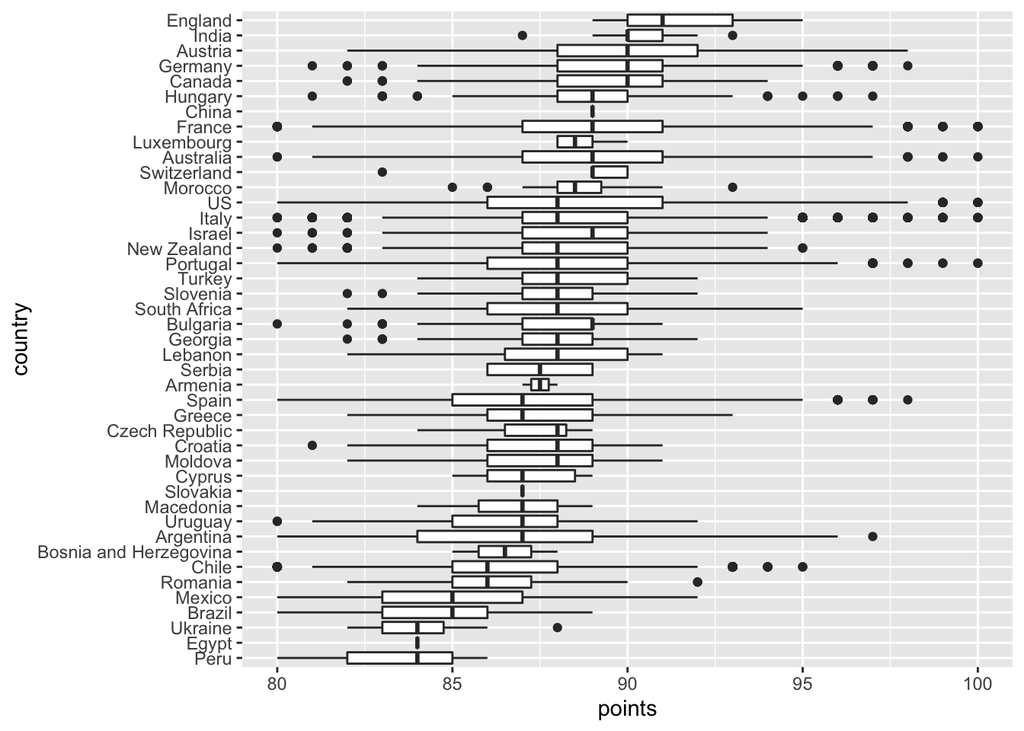

```r
wine %>%
        drop_na(country) %>%
        mutate(country = fct_reorder(country, .x = points, .fun = mean)) %>%
        ggplot(aes(x=country, y=points)) +
        geom_boxplot()+
        coord_flip()
```

And I don’t know about you, but I was higly surpriced to see that England and India were the two countries with the on average best wines!